# Another R Tutorial

steven

October 14, 2019

This introduction will focus on base R (and introduce tidyverse and RDataTable at the end).  
We will begin with creating vectors.

```r
x1 <- rpois(10, lambda = 1)

length(x1)
```

```
## [1] 10
```

```r
x1
```

```
##  [1] 4 1 1 1 0 4 3 2 0 1
```

```r
x1 + 1
```

```
##  [1] 5 2 2 2 1 5 4 3 1 2
```

```r
x1 ^ 2
```

```
##  [1] 16  1  1  1  0 16  9  4  0  1
```

```r
x2 <- rexp(20)
x2
```

```
##  [1] 0.28176709 0.56602587 1.24433304 0.38979821 1.32344552 0.17274020
##  [7] 0.21475756 0.31190761 0.25022551 0.76559523 1.20149118 1.26933501
## [13] 1.66089256 1.20795757 0.10833000 1.30614546 0.03922877 0.63040902
## [19] 1.68279915 0.69595185
```

Let’s do a quick plot of `x1`. If you only supply 1 vector, the `plot` function will plot by index.

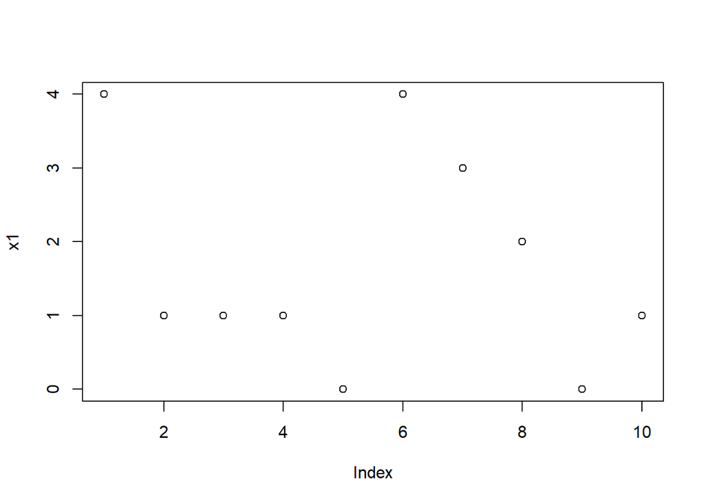

```r
plot(x1)
```

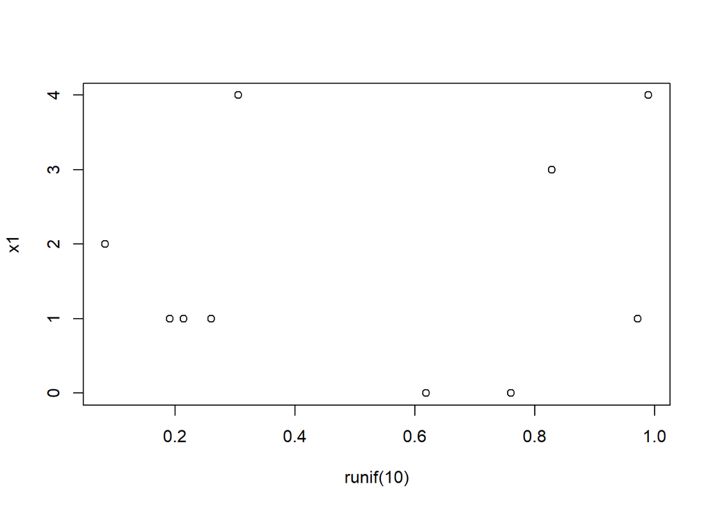

```r
plot(runif(10), x1)
```

Vectors allow index retrieval. `letters` is a built-in R vector that contains the lowercase alphabet.  
Index starts at 1.

```r
x3 <- letters[10]
x3
```

```
## [1] "j"
```

Lists are the foundation of R’s various data structures. They’re powerful but can be tricky to use at first.  
Each element of the list can be a different data structure. Here, we’ll just use the three vectors from before.

```r
list1 <- list(x1, x2, x3)
```

Base R has a famous family of functions that I like to call the “apply” family. `lapply` applies a function to each element of the list. Below, we’ll drop the last element from the list.

```r
lapply(list1[-3], mean)
```

```
## [[1]]
## [1] 1.7
##
## [[2]]
## [1] 0.7661568
```

```r
lapply(list1[-3], function(x) sum(x^2))
```

```
## [[1]]
## [1] 49
##
## [[2]]
## [1] 17.37897
```

You will most likely use dataframes instead. Dataframes can be thought of as a special case of lists (i.e. a “flat” list). We’ll read in a CSV file.

```r
pokemon <- read.csv("pokemon.csv", header = T, stringsAsFactors = F)
head(pokemon)
```

```
##                     abilities against_bug against_dark against_dragon
## 1 ['Overgrow', 'Chlorophyll']        1.00            1              1
## 2 ['Overgrow', 'Chlorophyll']        1.00            1              1
## 3 ['Overgrow', 'Chlorophyll']        1.00            1              1
## 4    ['Blaze', 'Solar Power']        0.50            1              1
## 5    ['Blaze', 'Solar Power']        0.50            1              1
## 6    ['Blaze', 'Solar Power']        0.25            1              1
##   against_electric against_fairy against_fight against_fire against_flying
## 1              0.5           0.5           0.5          2.0              2
## 2              0.5           0.5           0.5          2.0              2
## 3              0.5           0.5           0.5          2.0              2
## 4              1.0           0.5           1.0          0.5              1
## 5              1.0           0.5           1.0          0.5              1
## 6              2.0           0.5           0.5          0.5              1
##   against_ghost against_grass against_ground against_ice against_normal
```

[output cut: 48 more lines]

Let’s take a quick look at what columns are in the dataframe.

```r
colnames(pokemon)
```

```
##  [1] "abilities"         "against_bug"       "against_dark"
##  [4] "against_dragon"    "against_electric"  "against_fairy"
##  [7] "against_fight"     "against_fire"      "against_flying"
## [10] "against_ghost"     "against_grass"     "against_ground"
## [13] "against_ice"       "against_normal"    "against_poison"
## [16] "against_psychic"   "against_rock"      "against_steel"
## [19] "against_water"     "attack"            "base_egg_steps"
## [22] "base_happiness"    "base_total"        "capture_rate"
## [25] "classfication"     "defense"           "experience_growth"
## [28] "height_m"          "hp"                "japanese_name"
## [31] "name"              "percentage_male"   "pokedex_number"
## [34] "sp_attack"         "sp_defense"        "speed"
## [37] "type1"             "type2"             "weight_kg"
## [40] "generation"        "is_legendary"      "evolution_stage"
```

One recurring theme in R is that there are several ways to do the same thing. Here’s one way of subsetting columns.

```r
pokemon2 <- pokemon[, c("type1", "name", "is_legendary", "generation", "evolution_stage", "attack", "defense", "speed", "sp_attack", "sp_defense")]
```

You can also use column indices.

```r
head(pokemon[, c(37, 31, 41)])
```

```
##   type1       name is_legendary
## 1 grass  Bulbasaur            0
## 2 grass    Ivysaur            0
## 3 grass   Venusaur            0
## 4  fire Charmander            0
## 5  fire Charmeleon            0
## 6  fire  Charizard            0
```

Even logical indices!

```r
head(pokemon[, c(T, T, F, T)])
```

```
##                     abilities against_bug against_dragon against_electric
## 1 ['Overgrow', 'Chlorophyll']        1.00              1              0.5
## 2 ['Overgrow', 'Chlorophyll']        1.00              1              0.5
## 3 ['Overgrow', 'Chlorophyll']        1.00              1              0.5
## 4    ['Blaze', 'Solar Power']        0.50              1              1.0
## 5    ['Blaze', 'Solar Power']        0.50              1              1.0
## 6    ['Blaze', 'Solar Power']        0.25              1              2.0
##   against_fairy against_fire against_flying against_ghost against_ground
## 1           0.5          2.0              2             1              1
## 2           0.5          2.0              2             1              1
## 3           0.5          2.0              2             1              1
## 4           0.5          0.5              1             1              2
## 5           0.5          0.5              1             1              2
## 6           0.5          0.5              1             1              0
##   against_ice against_normal against_psychic against_rock against_steel
```

[output cut: 34 more lines]

We can use the `subset` function to, well, subset. We’ll subset the dataframe to the first 2 generations. We’ll then use the `unique` function as a check.

```r
pokemon_first_2_gen <- subset(pokemon2, pokemon2$generation %in% c(1, 2))

unique(pokemon_first_2_gen$generation)
```

```
## [1] 1 2
```

If you look at the documentation, there are many ways to set up the `aggregate` function. Here’s what I think is the easiest. We’ll find the average stats by type and generation.

```r
pokemon_stats <- aggregate(cbind(attack, defense, speed, sp_attack, sp_defense) ~ type1 + generation, data = pokemon_first_2_gen, mean)
pokemon_stats
```

```
##       type1 generation    attack   defense     speed sp_attack sp_defense
## 1       bug          1  71.25000  58.75000  64.58333  45.83333   57.08333
## 2    dragon          1  94.00000  68.33333  66.66667  73.33333   73.33333
## 3  electric          1  61.44444  64.11111 100.00000  91.66667   73.88889
## 4     fairy          1  57.50000  60.50000  47.50000  77.50000   77.50000
## 5  fighting          1 102.85714  61.00000  66.14286  45.00000   73.57143
## 6      fire          1  84.83333  62.58333  84.75000  88.75000   79.16667
## 7     ghost          1  50.00000  51.66667 101.66667 128.33333   61.66667
## 8     grass          1  73.00000  72.91667  51.25000  89.75000   66.66667
## 9    ground          1  84.37500  90.00000  56.25000  35.62500   52.50000
## 10      ice          1  67.50000  67.50000  90.00000 105.00000  110.00000
## 11   normal          1  68.86364  55.13636  70.22727  55.59091   61.68182
## 12   poison          1  75.14286  67.00000  58.78571  57.14286   61.64286
## 13  psychic          1  65.12500  57.50000  98.00000 113.75000   96.87500
## 14     rock          1  85.55556 112.22222  60.55556  61.66667   57.77778
```

[output cut: 17 more lines]

Let’s do a boxplot. we’ll subset to just the first generation as to not crowd the plot.

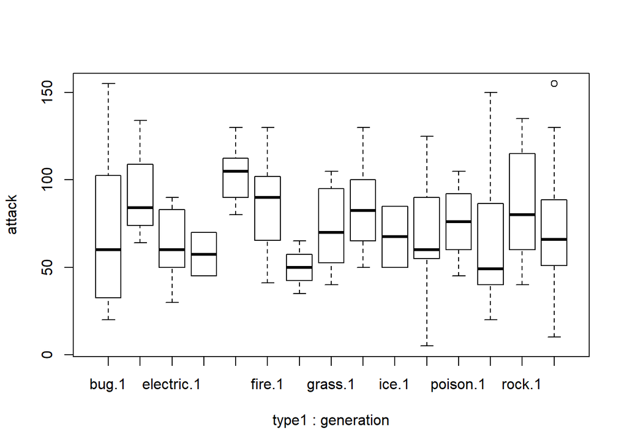

```r
boxplot(attack ~ type1 + generation, data = subset(pokemon2, pokemon2$generation == 1))
```

Let’s plot the aggregated data. We’ll use the `ggplot2` package as it will give us more control over the plot.

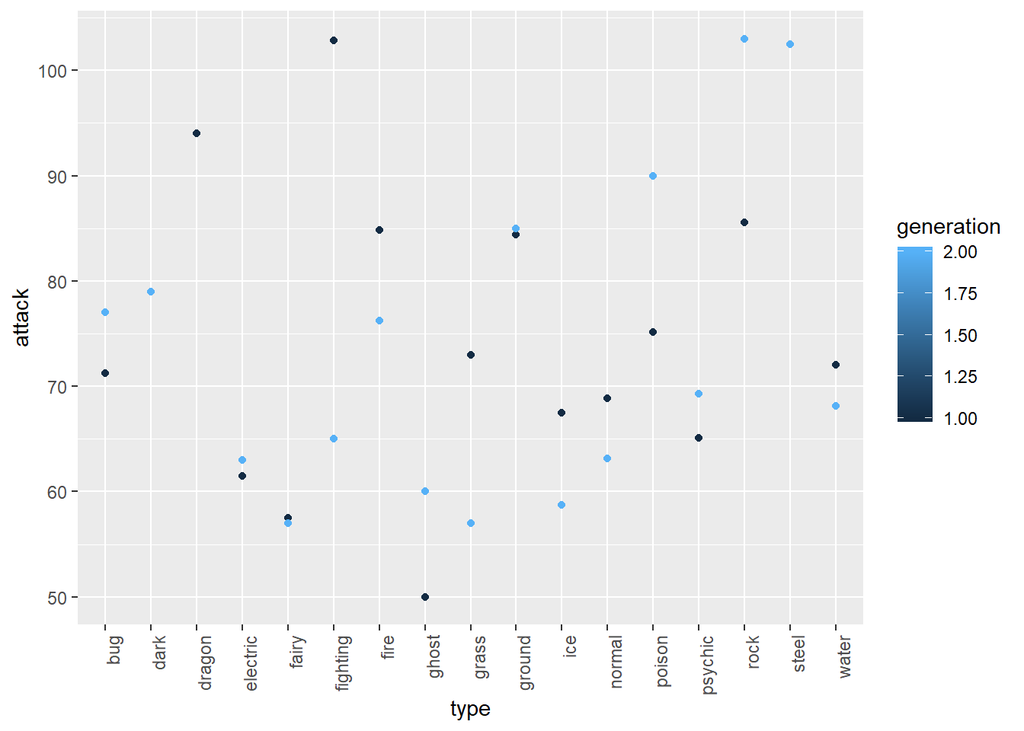

```r
library(ggplot2)
pokemon_stats$type = as.factor(pokemon_stats$type1)
ggplot(pokemon_stats, aes(type, attack, color = generation)) +
  geom_point(stat = "identity") +
  scale_fill_brewer(palette = "Set1") +
  theme(axis.text.x = element_text(angle = 90, hjust = 1))
```

```r
library(dplyr)
pkmn_stats_tidy <- pokemon_first_2_gen %>%
  filter(generation == 1) %>%
  group_by(type1) %>%
  summarize(attack = mean(attack),
            defense = mean(defense),
            speed = mean(speed),
            sp_attack = mean(sp_attack),
            sp_defense = mean(sp_defense))
pkmn_stats_tidy
```

```
## # A tibble: 15 x 6
##    type1    attack defense speed sp_attack sp_defense
##    <chr>     <dbl>   <dbl> <dbl>     <dbl>      <dbl>
##  1 bug        71.2    58.8  64.6      45.8       57.1
##  2 dragon     94      68.3  66.7      73.3       73.3
##  3 electric   61.4    64.1 100        91.7       73.9
##  4 fairy      57.5    60.5  47.5      77.5       77.5
##  5 fighting  103.     61    66.1      45         73.6
##  6 fire       84.8    62.6  84.8      88.8       79.2
##  7 ghost      50      51.7 102.      128.        61.7
##  8 grass      73      72.9  51.2      89.8       66.7
##  9 ground     84.4    90    56.2      35.6       52.5
## 10 ice        67.5    67.5  90       105        110
## 11 normal     68.9    55.1  70.2      55.6       61.7
## 12 poison     75.1    67    58.8      57.1       61.6
## 13 psychic    65.1    57.5  98       114.        96.9
## 14 rock       85.6   112.   60.6      61.7       57.8
## 15 water      72.0    81.8  67.7      68.0       67.8
```

```r
print.data.frame(pkmn_stats_tidy)
```

```
##       type1    attack   defense     speed sp_attack sp_defense
## 1       bug  71.25000  58.75000  64.58333  45.83333   57.08333
## 2    dragon  94.00000  68.33333  66.66667  73.33333   73.33333
## 3  electric  61.44444  64.11111 100.00000  91.66667   73.88889
## 4     fairy  57.50000  60.50000  47.50000  77.50000   77.50000
## 5  fighting 102.85714  61.00000  66.14286  45.00000   73.57143
## 6      fire  84.83333  62.58333  84.75000  88.75000   79.16667
## 7     ghost  50.00000  51.66667 101.66667 128.33333   61.66667
## 8     grass  73.00000  72.91667  51.25000  89.75000   66.66667
## 9    ground  84.37500  90.00000  56.25000  35.62500   52.50000
## 10      ice  67.50000  67.50000  90.00000 105.00000  110.00000
## 11   normal  68.86364  55.13636  70.22727  55.59091   61.68182
## 12   poison  75.14286  67.00000  58.78571  57.14286   61.64286
## 13  psychic  65.12500  57.50000  98.00000 113.75000   96.87500
## 14     rock  85.55556 112.22222  60.55556  61.66667   57.77778
## 15    water  72.03571  81.78571  67.71429  68.03571   67.82143
```

```r
library(data.table)
pokemon_dt <- fread(file = "pokemon.csv")
pkmn_stats_dt <- pokemon_dt[generation == 1,
                             .(attack = mean(attack),
                                defense = mean(defense),
                                speed = mean(speed),
                                sp_attack = mean(sp_attack),
                                sp_defense = mean(sp_defense)),
                             by = "type1"][order(type1)]

pkmn_stats_dt
```

```
##        type1    attack   defense     speed sp_attack sp_defense
##  1:      bug  71.25000  58.75000  64.58333  45.83333   57.08333
##  2:   dragon  94.00000  68.33333  66.66667  73.33333   73.33333
##  3: electric  61.44444  64.11111 100.00000  91.66667   73.88889
##  4:    fairy  57.50000  60.50000  47.50000  77.50000   77.50000
##  5: fighting 102.85714  61.00000  66.14286  45.00000   73.57143
##  6:     fire  84.83333  62.58333  84.75000  88.75000   79.16667
##  7:    ghost  50.00000  51.66667 101.66667 128.33333   61.66667
##  8:    grass  73.00000  72.91667  51.25000  89.75000   66.66667
##  9:   ground  84.37500  90.00000  56.25000  35.62500   52.50000
## 10:      ice  67.50000  67.50000  90.00000 105.00000  110.00000
## 11:   normal  68.86364  55.13636  70.22727  55.59091   61.68182
## 12:   poison  75.14286  67.00000  58.78571  57.14286   61.64286
## 13:  psychic  65.12500  57.50000  98.00000 113.75000   96.87500
## 14:     rock  85.55556 112.22222  60.55556  61.66667   57.77778
## 15:    water  72.03571  81.78571  67.71429  68.03571   67.82143
```